# OS FATORES QUE INFLUENCIAM NA NOTA DO ENEM ALÉM DOS ESTUDOS - Análise do ENEM 2019 - Projeto Final Semantix

Gleidson Gomes

04/12/2021

# 1 - Introdução

O presente trabalho apresenta uma análise realizada na base de dados do Exame Nacional do Ensino Médio (ENEM). É baseado no artigo intitulado “Impacto das variáveis socioeconômicas no desempenho do ENEM: uma análise espacial e sociológica”, publicado na Revista de Administração Pública [SOUZA].

Segundo o artigo, grande parte dos fatores como infraestrutura e socioeconômico influenciam na nota do ENEM.

Para chegar aos resultados, os autores fizeram um levantamento das notas da prova objetiva e da redação dos alunos que realizaram o exame em 2018. Depois, cruzaram os números com três bases de dados diferentes: dos questionários socioeconômicos do exame, das informações do Censo Escolar de 2018 e de estatísticas do Instituto Brasileiro de Geografia e Estatística (IBGE) [SOUZA].

# 2 - Objetivo

O objetivo principal deste trabalho é compreender se os fatores como infraestrutura e socioeconômico influenciam na nota do ENEM por meio da análise dos dados do exame realizado em 2019. Melhorar o entendimento sobre o desempenho do ENEM no tocante ao que foje às exaustivas horas de estudo do inscrito.

Será realizado o cruzamento das notas das provas de Ciências da Natureza, Ciências Humanas, Linguagens e Códigos, Matemática e Redação com os questionários socioeconômicos do exame do mesmo ano. A variável de interesse (Nota geral da prova) será calculada por meio do somatório das notas das provas citadas acima, no qual irá refletir o desempenho geral do inscrito. Foram consideradas para às análises às inscrições:

- Sem a indicação se o inscrito fez a prova com intuito de apenas treinar seus conhecimentos;
- Com presença nas provas objetivas de Ciências da Natureza, Ciências Humanas, Linguagens e Códigos e Matemática;
- Com a situação da redação do participante como sem problemas;
- Situação de conclusão do Ensino Médio como já concluído.

Este trabalho está organizado em capítulos. O capítulo 1 traz uma breve visão do artigo. O capítulo 2 apresenta o plano analítico, justifica e restringe a análise a ser feita. O capítulo 3 demonstra a metodologia aplicada. O capítulo 4 descreve a preparação da base e faz a análise exploratória dos dados. O capítulo 5 descreve a modelagem analítica. O capítulo 6 conclui o trabalho com resultado alcançado e *insight* percebido. O capítulo 7 apresenta as referências bibliográficas.

# 3 - Metodologia

A metodologia a ser utilizada neste trabalho é baseado no ciclo de vida de projeto analítico adaptada da proposta de [TODD] que consiste em criar o plano analítico, a análise exploratória dos dados (predição) e a modelagem analítica. A Figura 1 ilustra a proposta de [TODD]:

[figure not shown]

**Figura 1: Data Analytics Lifecycle (TODD).**

A Figura 2 mostra a metodologia proposta para o trabalho adaptada da proposta de [TODD]. Note que o processo é sequencial, porém, cada tarefa poderá ser revisitada diversas vezes para obter melhores resultados.

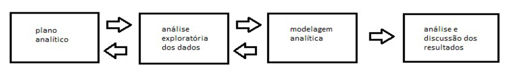

**Figura 2: Etapa da Metodologia Proposta Adaptado de (TODD).**

Os tópicos a seguir descrevem cada etapa da metodologia:

- Plano Analítico:

O plano analítico consiste em registrar o problema a ser tratado. Nesta etapa é realizada a descrição do problema ou investigação a ser resolvida; formulação de hipóteses iniciais que poderiam resolver o problema; descrever um escopo para o problema; realizar o planejamento do modelo, onde será descoberto o tipo de problema, sendo uma classificação, agrupamento ou previsão e a melhor forma para resolver o problema; análise dos resultados esperados; listagem do valor que o resultado agregará ao negócio e a comunicação dos resultados [TODD].

- Análise Exploratória dos Dados:

A análise exploratória dos dados permite criar condições para a análise e exploração dos dados. Nesta etapa é realizada a verificação de condições para a exploração dos dados, como a definição da fonte de dados, permissão de acesso, uso da informação e capacidade para processamento dos dados; avaliar a qualidade dos dados; realizar a extração, transformação e limpeza dos dados; extração de medidas estatísticas para análise dos dados, como média, mediana, variância, valores nulos, distribuição, histograma [TODD].

- Modelagem Analítica:

Nesta fase da metodologia é possível definir a modelagem apropriada para resolver o problema descrito. Nesta etapa é levantado os métodos candidatos, exploração dos dados, adaptação e execução do modelo [TODD].

- Resultados:

Consiste na avaliação, apresentação e comunicação dos resultados alcançados. Nesta etapa é validada se o modelo alcançou boa acurácia para o subconjunto de teste, verificação se os resultados são válidos no contexto, bem como o levantamento de *insights* encontrados [TODD].

# 4 - Preparação da base e análise exploratória dos dados

## Limpeza das variáveis de sistema e memória

## Instalação das bibliotecas no R

## Cálculo do tamanho da amostra

Os dados completos do ENEM foram importados para uma base intermediária onde foi possibilitada a amostragem aleatória simples sem reposição (AASs) para as análises [BOLFARINE]. A obtenção do tamanho da amostra foi realizado com a seguinte fórmula [LEVIN]:

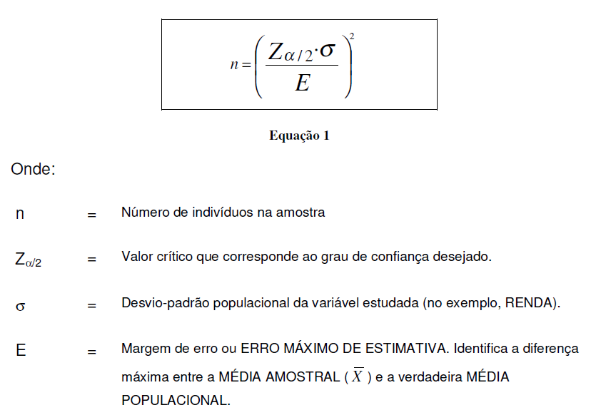

**Figura 3: Fórmula para cálculo do tamanho da amostra para uma estimativa confiável da média populacional (LEVIN).**

O tamanho da população com os inscritos considerados para a análise conforme regra descrita no Capítulo 2 é 1.903.088. Para o cálculo do tamanho da amostra, foram consideradas margem de erro de 5 pontos, valor crítico de 1.96 (para o intervalo de confiança de 95%), desvio padrão polulacional de 396,0966 para um resultado final do tamanho da amostra de 24.109. A função *sample* do R foi utilizada para selecionar amostras de uma população com base nos parâmetros acima.

Com isso, uma nova base foi criada conforme os parâmetros de interesse e seleção das variáveis promissoras oriundas de pesquisas realizadas sobre o assunto para início da análise dos dados. A base foi carregada conforme segue abaixo:

## Importação dos dados do ENEM com filtros e registros selecionados

## Visualização dos 5 primeiros registros

| NU_IDADE | TP_SEXO | TP_ESTADO_CIVIL | TP_COR_RACA | TP_NACIONALIDADE | TP_ANO_CONCLUIU | TP_ESCOLA | TP_ENSINO | TP_LOCALIZACAO_ESC | TP_SIT_FUNC_ESC | NU_NOTA_CN | NU_NOTA_CH | NU_NOTA_LC | NU_NOTA_MT | NU_NOTA_REDACAO | NU_NOTA_GERAL | TP_REGIAO_RESIDENCIA | TP_GRAU_INSTRUCAO_MULHER | TP_RENDA_MENSAL | TP_RESIDENCIA_TEM_PC | TP_RESIDENCIA_TEM_INTERNET |
| --- | --- | --- | --- | --- | --- | --- | --- | --- | --- | --- | --- | --- | --- | --- | --- | --- | --- | --- | --- | --- |
| 19 | Feminino | Solteiro(a) | Preta | Brasileiro(a) | 3 | Não respondeu | NA | NA | NA | 431.7 | 568.9 | 562.4 | 521.1 | 680 | 2764.1 | Sul | Não completou 4 Série | Acima 2 até 3 salários | Não | Sim |
| 20 | Feminino | Solteiro(a) | Branca | Brasileiro(a) | 4 | Não respondeu | NA | NA | NA | 523.0 | 590.2 | 582.8 | 666.2 | 740 | 3102.2 | Sul | Completou Faculdade | Acima 3 até 6 salários | Sim, um | Sim |
| 25 | Maculino | Solteiro(a) | Parda | Brasileiro(a) | 9 | Não respondeu | Ensino Regular | NA | NA | 528.9 | 598.8 | 572.1 | 381.0 | 600 | 2680.8 | Centro-Oeste | Completou Ensino Médio | Acima 1 até 2 salários | Não | Sim |
| 18 | Feminino | Solteiro(a) | Não declarado | Brasileiro(a) | 2 | Não respondeu | NA | NA | NA | 466.4 | 542.9 | 545.5 | 515.5 | 700 | 2770.3 | Nordeste | Não completou 4 Série | Nenhuma renda | Não | Não |
| 18 | Feminino | Solteiro(a) | Parda | Brasileiro(a) | 2 | Não respondeu | Ensino Regular | NA | NA | 437.5 | 483.4 | 503.6 | 558.5 | 840 | 2823.0 | Nordeste | Completou Ensino Médio | Até 1 salário | Não | Sim |

```
## [1] 24109    21
```

```
##     NU_IDADE         TP_SEXO           TP_ESTADO_CIVIL
##  Min.   :14.00   Maculino: 9659   Não informado:  952
##  1st Qu.:19.00   Feminino:14450   Solteiro(a)  :20128
##  Median :21.00                    Casado(a)    : 2511
##  Mean   :24.28                    Divorciado(a):  478
##  3rd Qu.:26.00                    ViÚvo(a)     :   40
##  Max.   :74.00
##
##                 TP_COR_RACA                        TP_NACIONALIDADE
##  Não declarado        :  437   Não informado               :   32
##  Branca               : 7918   Brasileiro(a)               :23479
##  Preta                : 3413   Naturalizado(a)             :  559
##  Parda                :11629   Estrangeiro(a)              :   18
##  Amarela              :  575   Nato(a), nascido(a) exterior:   21
##  Indígena             :  137
##  Não dispõe informação:    0
##  TP_ANO_CONCLUIU          TP_ESCOLA                            TP_ENSINO
##  Min.   : 1.000   Não respondeu:24109   Ensino Regular              :11959
##  1st Qu.: 2.000   Pública      :    0   Educação Especial           :   52
##  Median : 4.000   Privada      :    0   Educação de Jovens e Adultos:    0
##  Mean   : 5.664   Exterior     :    0   NA's                        :12098
##  3rd Qu.: 8.000
##  Max.   :14.000
##
##  TP_LOCALIZACAO_ESC                TP_SIT_FUNC_ESC    NU_NOTA_CN
##  Urbana:    0       Em atividade           :    0   Min.   :  0.0
##  Rural :    0       Paralisada             :    0   1st Qu.:419.8
##  NA's  :24109       Extinta                :    0   Median :472.7
##                     Extinta anos anteriores:    0   Mean   :480.0
##                     NA's                   :24109   3rd Qu.:533.7
##                                                     Max.   :799.0
##
##    NU_NOTA_CH      NU_NOTA_LC      NU_NOTA_MT    NU_NOTA_REDACAO NU_NOTA_GERAL
##  Min.   :  0.0   Min.   :  0.0   Min.   :  0.0   Min.   :100     Min.   : 380
##  1st Qu.:454.1   1st Qu.:488.6   1st Qu.:432.9   1st Qu.:500     1st Qu.:2338
##  Median :515.8   Median :529.2   Median :496.3   Median :580     Median :2575
##  Mean   :513.1   Mean   :525.0   Mean   :520.3   Mean   :591     Mean   :2630
##  3rd Qu.:571.4   3rd Qu.:567.5   3rd Qu.:593.4   3rd Qu.:680     3rd Qu.:2871
##  Max.   :771.1   Max.   :742.1   Max.   :967.0   Max.   :980     Max.   :4080
##
```

[output cut: 9 more lines]

```
##  Nenhuma renda         :1011   Não                :10721
##  Até 1 salário         :5929   Sim, um            :11029
##  Acima 1 até 2 salários:9200   Sim, dois          : 1709
##  Acima 2 até 3 salários:3491   Sim, três          :  485
##  Acima 3 até 6 salários:2836   Sim, quatro ou mais:  165
##  Acima 6 salários      :1642
##
##  TP_RESIDENCIA_TEM_INTERNET
##  Não: 5448
##  Sim:18661
##
##
##
##
##
```

## Análise exploratória dos dados univariada

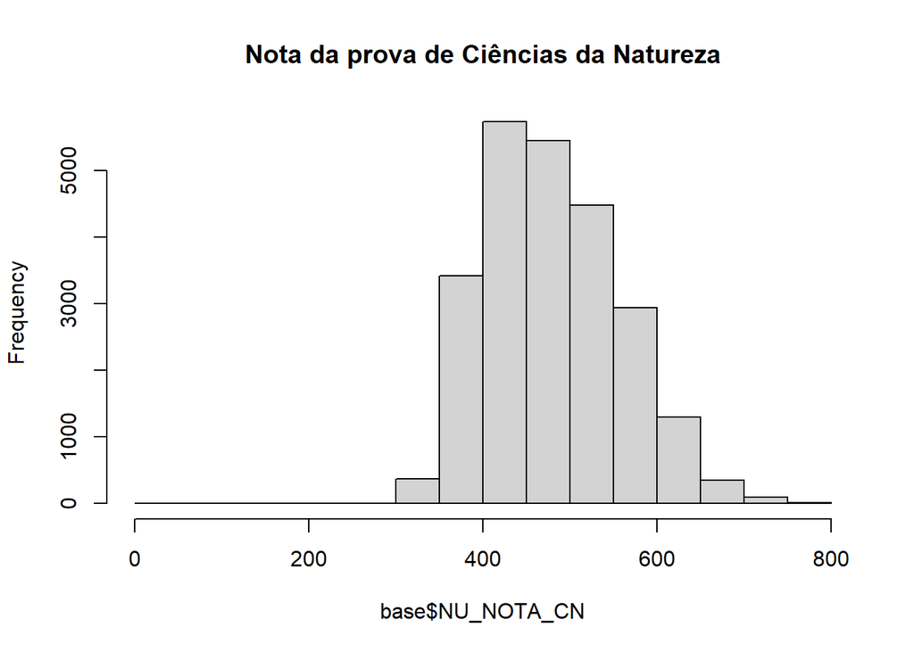

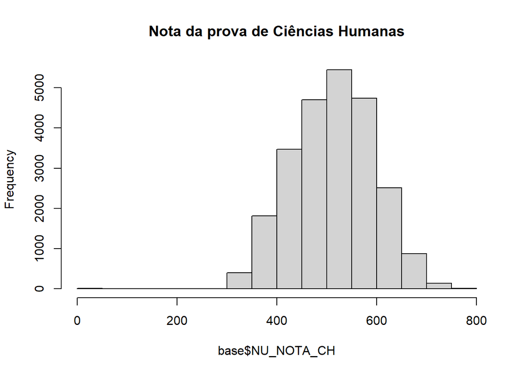

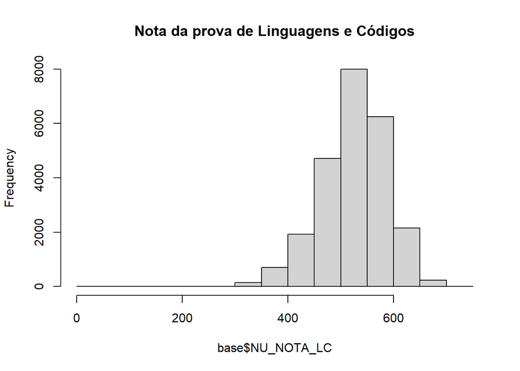

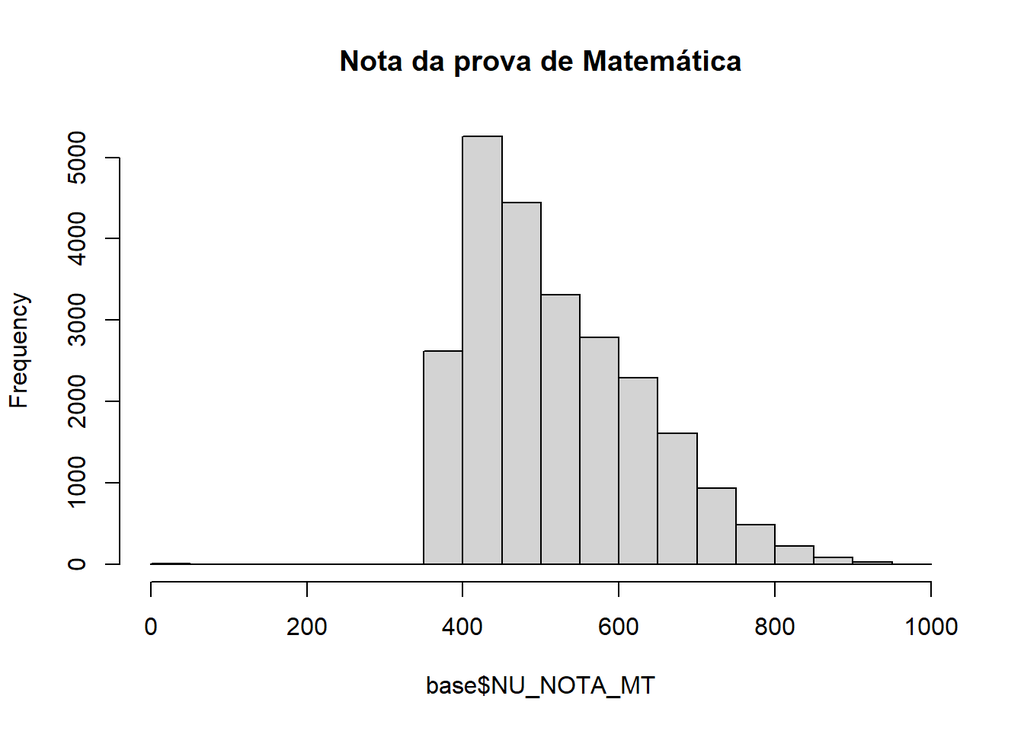

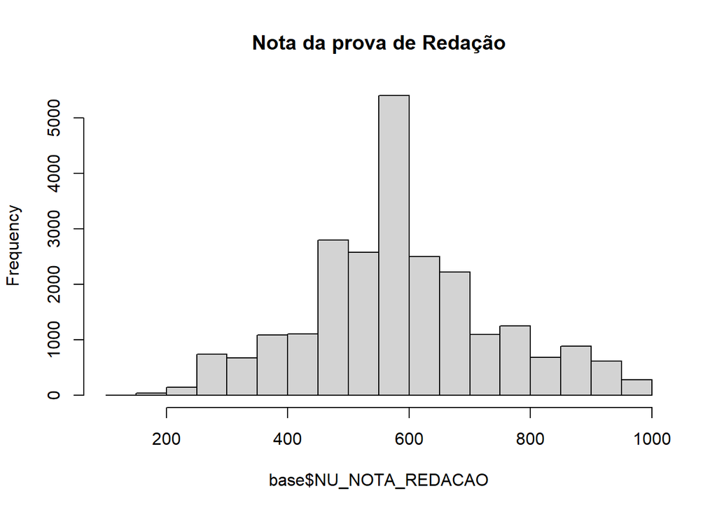

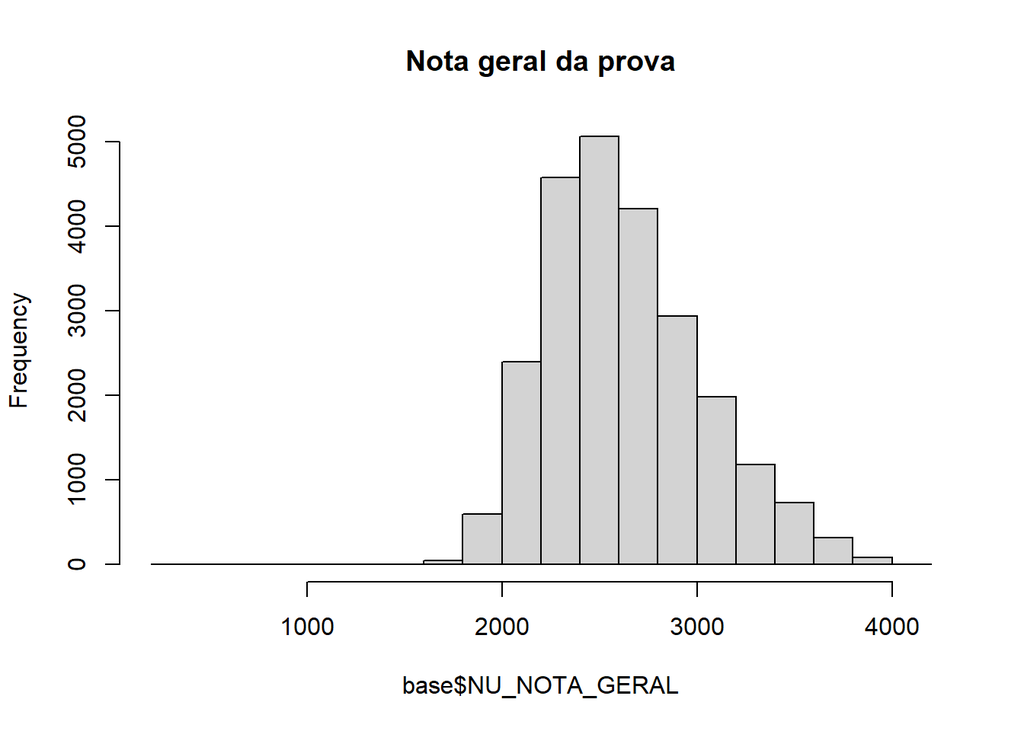

## Análise exploratória dos dados multivariada

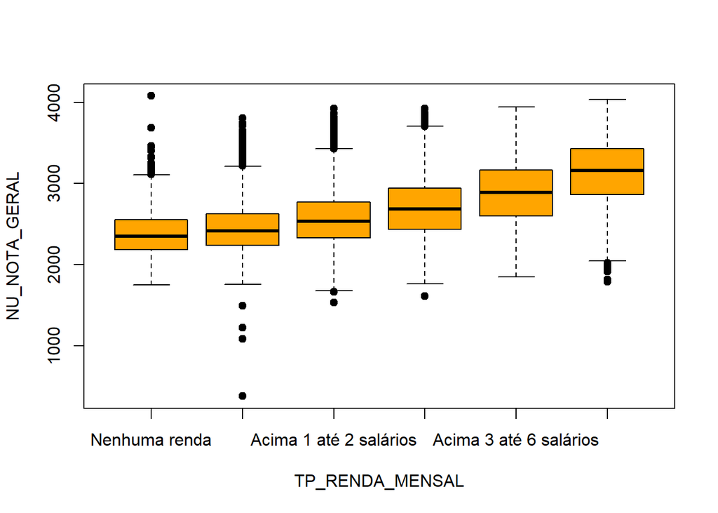

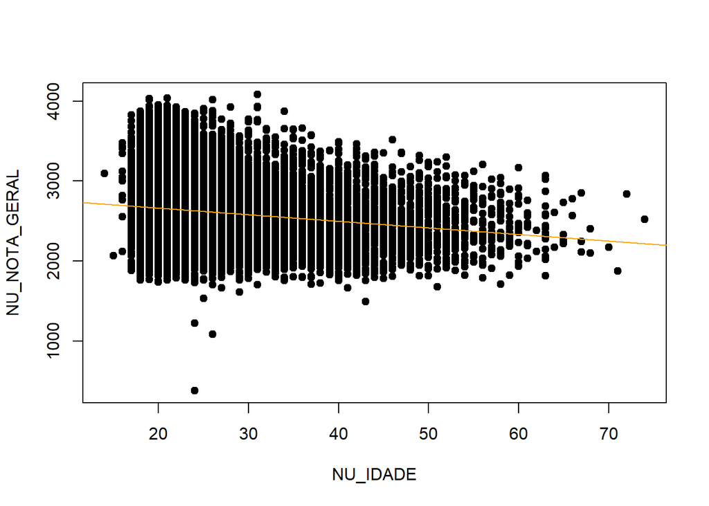

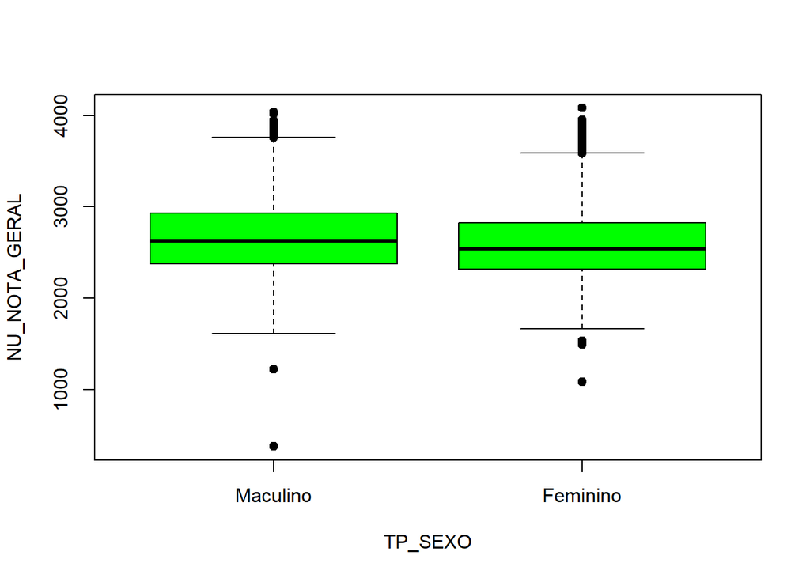

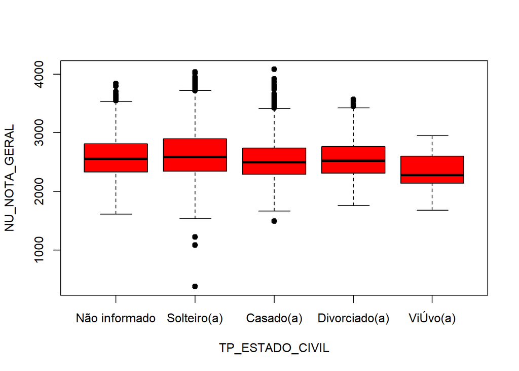

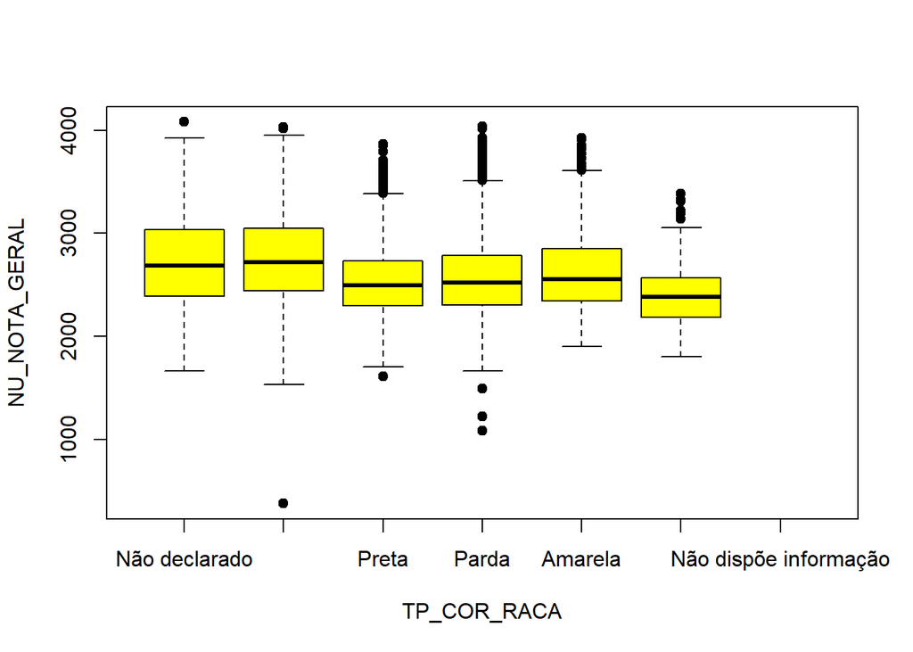

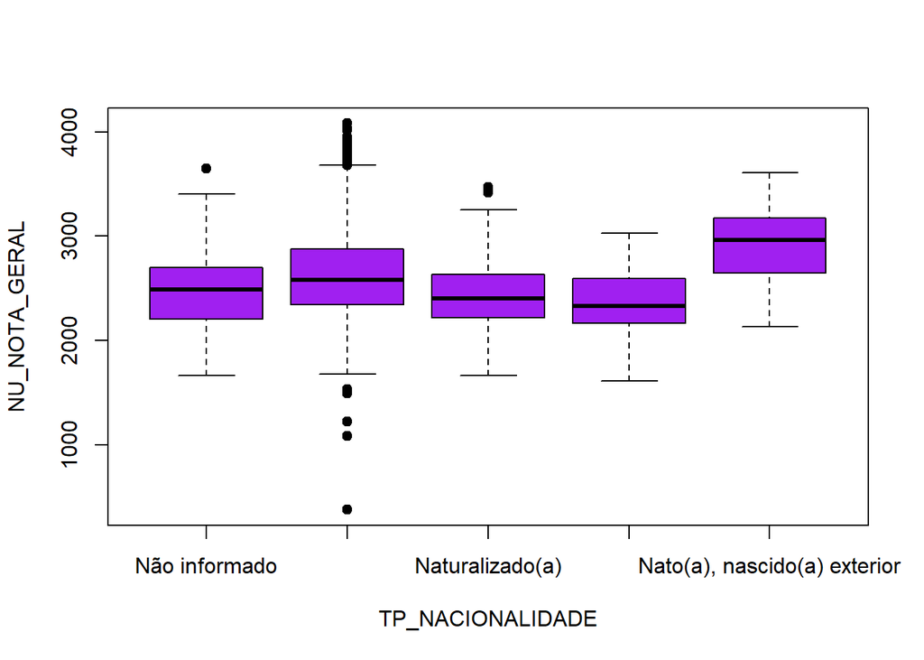

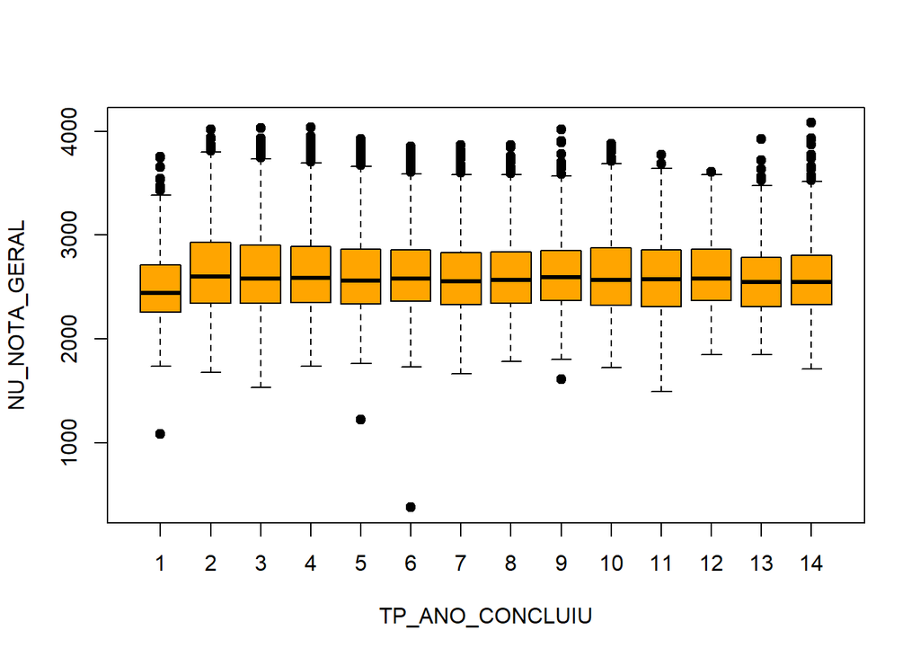

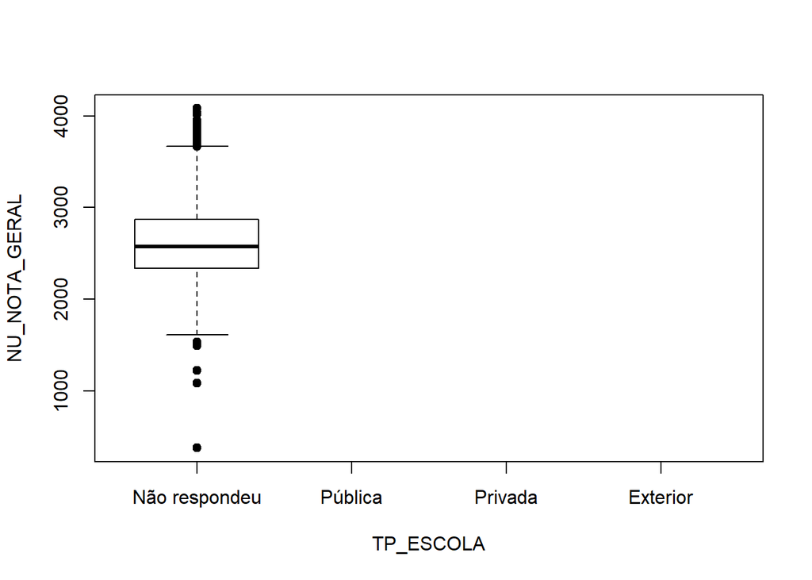

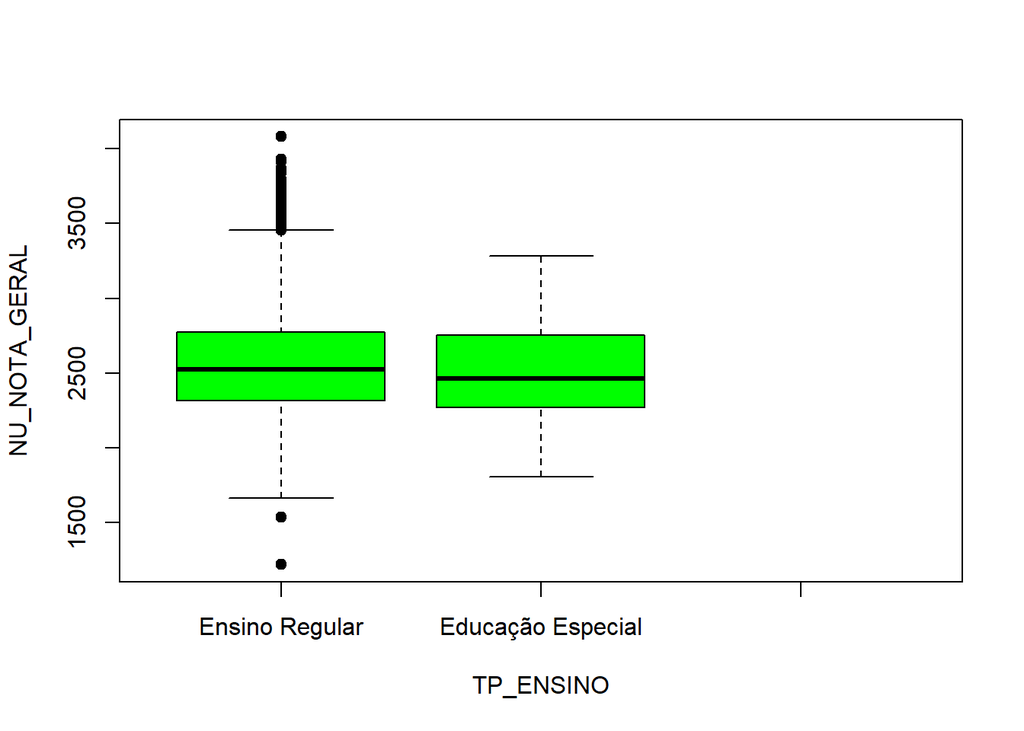

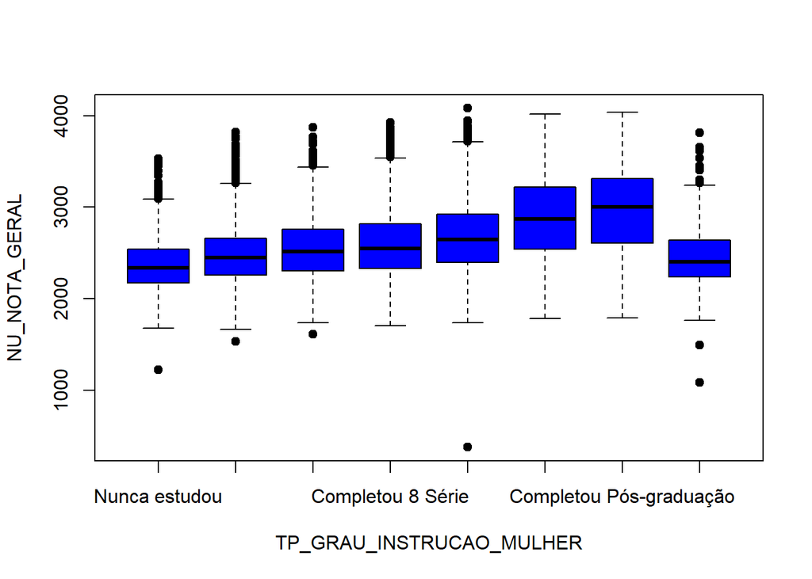

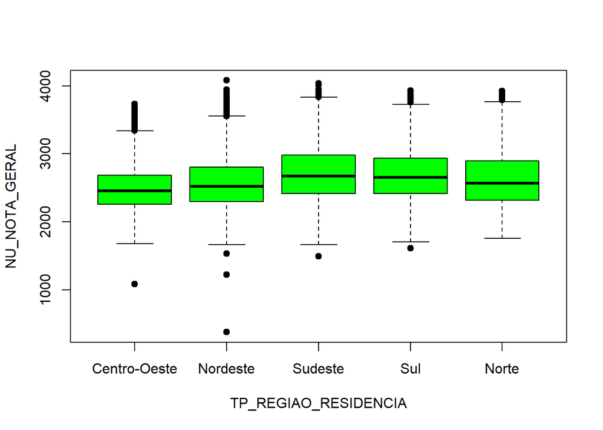

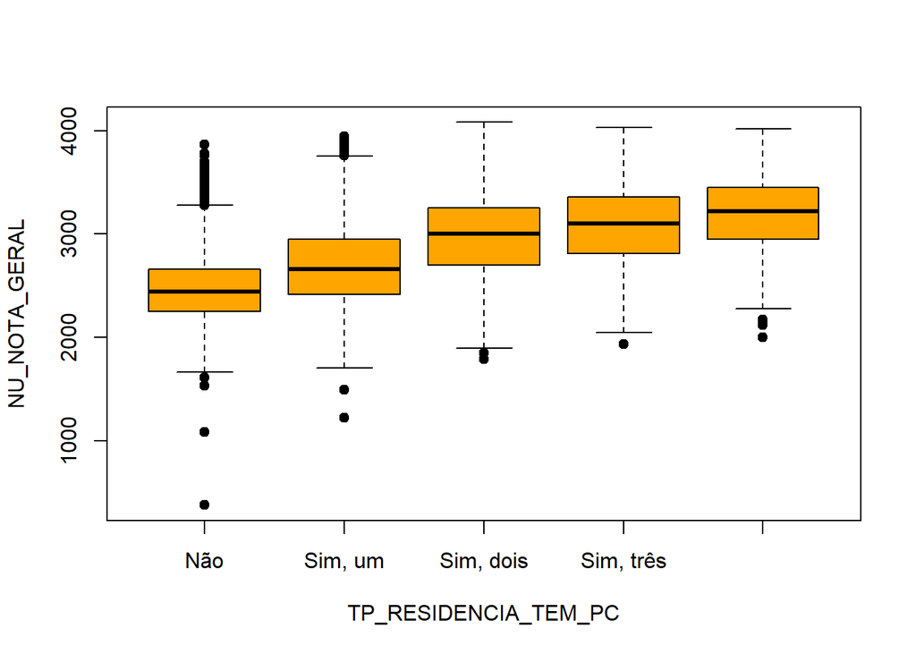

[6 more figures not shown]